# M1-9: Supervised Machine Learning 2: Model boosting, diagnostics, explanation

Daniel S. Hain (dsh@business.aau.dk)

14/09/2018

Some housekeeping (again), installing necessary packages.

```r
list.of.packages <- c("knitr",
                      "data.table",
                      "caret",
                      "caretEnsemble",
                      "recipes"
                      )
new.packages <- list.of.packages[!(list.of.packages %in% installed.packages()[,"Package"])]
if(length(new.packages)) install.packages(new.packages)
rm(list.of.packages, new.packages)
```

# Preample: Load all ourstuff from last time

We will go on working a bit with our previous dataset, so let’s just run the last routie again:

```r
# Read data
data <- readRDS("data/telco_churn.rds")
# Mini manual preprocessing
data %<>%
  select(-customerID) %>%
  drop_na() %>%
  select(Churn, everything())
# Split in training and test
library(caret)
index <- createDataPartition(y = data$Churn, p = 0.75, list = FALSE)
training <- data[index,]
test <- data[-index,]
# Do the preprocessing recipe
library(recipes)
reci <- recipe(Churn ~ ., data = training) %>%
  step_discretize(tenure, options = list(cuts = 6)) %>%
  step_log(TotalCharges) %>%
  step_dummy(all_nominal(), -all_outcomes()) %>%
  step_center(all_predictors(), -all_outcomes()) %>%
  step_scale(all_predictors(), -all_outcomes()) %>%
  prep(data = training)
# Split in x/y & train/test
x_train <- bake(reci, newdata = training) %>% select(-Churn)
x_test  <- bake(reci, newdata = test) %>% select(-Churn)
y_train <- pull(training, Churn) %>% as.factor()
y_test  <- pull(test, Churn) %>% as.factor()
# Remove what we dont need anymore
rm(data, index, reci)
```

We will also define the `caret` `traincontrol` parameters:

```r
ctrl <- trainControl(method = "cv", number = 10,
                     classProbs = TRUE,  summaryFunction = twoClassSummary,
                     returnData = FALSE, returnResamp = "final", savePredictions = "final", verboseIter = FALSE)
metric <- "ROC" # Which metric should be optimized (more on that later)
```

# Some ML tricks

## Bagging, boosting, bootstrapping

There are several useful ways to improve classifier performance. Interestingly enough, some of these methods work by adding randomness to the data. This seems paradoxical at first, but adding randomness turns out to be a helpful way of dealing with the overfitting problem.

- **Bootstraping** involves choosing (with replacement) a sample of size `n` from a dataset of size `n` to estimate the sampling distribution of some statistic. A variation is “`m` out of `n` bootstrap” which draws a sample of size `m` from a dataset of size `n`> `m`. THta’s what we usually use for cross-validation. It is therefore mainly a technique for hyperparameter tuning.
- **Bagging** stands for bootstrap aggregating. Bagging involves averaging across models estimated with several different bootstrap samples in order to improve the performance of an estimator. Here, each tree is build independently to the others. Bagging is primarily useful for nonlinear models such as trees. It is mainly a technique fordecreasing the out-of-sample error.
- **Boosting** involves repeated estimation where misclassified observations are given increasing weight in each repetition. The final estimate is then a vote or an average across the repeated estimates. Boosting tends to improve predictive performance an estimator significandy and can be used for pretty much any kind of classifier or regression model, including logits, probits, trees, and so on. Became lately increasingly hyped.

## Application

In the following, I will demonstrate the application of some cool trending ML algorythms, which leverage some of the abovementioned techniques. You will see that they follow quite diverse methodologies and approaches (I explein the intuition briefly, but at this stage don’t bother with the details). The idea is to dount you to the right packages in case you want to use them at one point later, and get a feeling for them. I also show that they are executed exactly with the same code as the 180+ other algorithms included in `caret`. So, don’t be afraid of different algorithms :)

### Random Forest (Baseline)

Lets start with a random forest, which you know by now.

```r
library(ranger)
fit.rf <- train(x = x_train,
                y = y_train,
                trControl = ctrl,
                metric = metric,
                method = "ranger",
                importance = "impurity",
                tuneLength = 4,
                num.trees = 25)
```

```r
fit.rf
```

```
Random Forest

No pre-processing
Resampling: Cross-Validated (10 fold)
Summary of sample sizes: 4748, 4746, 4748, 4748, 4748, 4748, ...
Resampling results across tuning parameters:

  mtry  splitrule   ROC        Sens       Spec
   2    gini        0.8288830  0.9465543  0.3537842
   2    extratrees  0.8298332  0.9481093  0.3330395
  13    gini        0.8049724  0.8920836  0.4836373
  13    extratrees  0.7998852  0.8838162  0.4879129
  24    gini        0.7986023  0.8820060  0.4814995
  24    extratrees  0.7897408  0.8789126  0.4885917
  35    gini        0.7953486  0.8804663  0.4786322
  35    extratrees  0.7893116  0.8768394  0.4757599

Tuning parameter 'min.node.size' was held constant at a value of 1
ROC was used to select the optimal model using the largest value.
The final values used for the model were mtry = 2, splitrule = extratrees and min.node.size = 1.
```

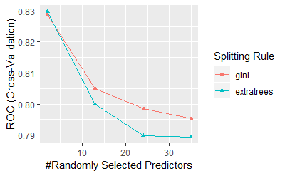

```r
ggplot(fit.rf)
```

### Support Vector Machines (SVM)

Briefly, SVM works by identifying the optimal decision boundary that separates data points from different groups (or classes), and then predicts the class of new observations based on this separation boundary. Depending on the situations, the different groups might be separable by a linear straight line or by a non-linear boundary line. Support vector machine methods can handle both linear and non-linear class boundaries. It can be used for both two-class and multi-class classification problems. In real life data, the separation boundary is generally nonlinear. Technically, the SVM algorithm perform a non-linear classification using what is called the kernel trick. The most commonly used kernel transformations are polynomial kernel and radial kernel. Note that, there is also an extension of the SVM for regression, called support vector regression.

```r
library(kernlab)
fit.svm <- train(x = x_train,
                y = y_train,
                trControl = ctrl,
                metric = metric,
                method = "svmRadial",
                verbose = FALSE,
                tuneLength = 4)
```

[figure not shown]